# Variable Selection Question 2

Mary Fisher

February 28, 2020

#### Research Question: Can we predict giant kelp size and abundance from oceanographic conditions and herbivore abundance (predictor)?

**Response variables:** Giant kelp mean abundance, max abundance; Giant kelp mean size, maximum size.

**Predictor variables:**

1. Urchin abundance: Sea urchins are herbivores, and in large numbers (also called “herds”) can decimate kelp forests. We have three measures of urchin abundance - red urchin abundance, purple urchin abundance, and urchin abundance across all species.
2. Water chemistry: Like any algae / plant, kelp requires nutrients to grow. We have measurements for the following nutrients: nitrogen, ammonia, urea, and phosphorus. We also have chlorophyl concentrations, which is a general index of primary productivity.
3. Water temperature: All species have a thermal range, or a range of temperatures, at which they grow best; the degree of variability in temperature can also have an impact on growth. With kelp forest loss from recent marine heatwaves and long-term warming, there has been much interest in whether kelp are impacted by an absolute temperature threshold, or by the degree of variability in temperature. We have mean summer and mean winter temperatures, and variation in summer and mean winter temperatures.
4. Giant kelp mean / max abundance, mean / max size at t-1: This data set is a time series, so the giant kelp response variable at a given site for year `t` should be dependent on giant kelp condition in year `t-1`.

Read in data

```r
mydat <- read.csv(here::here("data","kelp_prediction_data_complete.csv")) %>%
  clean_names()
head(mydat)
```

```
##   year month site transect mapy_mean_abund mapy_max_abund mapy_mean_size
## 1 2002     8 CARP        1       0.6245833            0.8       15.48148
## 2 2002     8 CARP        2       0.0000000            0.0             NA
## 3 2002     8 CARP        3       0.0000000            0.0             NA
## 4 2002     8 CARP        4       0.0000000            0.0             NA
## 5 2002     8 CARP        5       0.0000000            0.0             NA
## 6 2002     8 CARP        6       0.0000000            0.0             NA
##   mapy_max_size franciscanus_abundance purpuratus_abundance urchin_abundance
## 1            30                      9                   92              101
## 2            NA                      2                  144              146
## 3            NA                      6                  138              144
## 4            NA                      2                  431              433
## 5            NA                      5                  312              317
## 6            NA                      9                  334              343
##   max_ammonia max_no2_no3 max_po4  max_poc max_pon max_tchl mean_ammonia
```

[output cut: 20 more lines]

Add in the giant kelp response variables for `t-1`.

```r
# need kelp info from 2001
kelp_dat <- read.csv(here::here("data","Annual_Kelp_MeanSize_MeanAbund_2001-2018.csv")) %>%
  clean_names() %>%
  filter(site %in% mydat$site & year == 2001) %>%
  dplyr::select(-scientific_name,-group, -month) %>%
  rename("prev_mean_abund" = mapy_mean_abund,"prev_max_abund"=mapy_max_abund,
         "prev_mean_size"=mapy_mean_size,"prev_max_size"=mapy_max_size) %>%
  mutate(year = year + 1)
kelp_prev <- read.csv(here::here("data","kelp_prediction_data.csv")) %>%
  clean_names() %>%
  dplyr::select(year,month,site,transect,
                                     mapy_mean_abund,mapy_max_abund,mapy_mean_size,mapy_max_size) %>%
  rename("prev_mean_abund" = mapy_mean_abund,"prev_max_abund"=mapy_max_abund,
         "prev_mean_size"=mapy_mean_size,"prev_max_size"=mapy_max_size) %>%
  mutate(year = year + 1) %>%
  dplyr::select(-month) %>%
  rbind(kelp_dat)
mydat <- left_join(mydat,kelp_prev,by=c("year","site","transect"))
message("\nThere are ", sum(is.na(mydat$prev_mean_abund)), " missing measurements for the previous year's kelp abundance.\n")
```

```
##
## There are 0 missing measurements for the previous year's kelp abundance.
```

```r
head(mydat %>% dplyr::select(year,site,transect,mapy_mean_abund,prev_mean_abund,prev_max_abund,prev_mean_size,prev_max_size))
```

```
##   year site transect mapy_mean_abund prev_mean_abund prev_max_abund
## 1 2002 CARP        1       0.6245833       0.3130952      0.5333333
## 2 2002 CARP        2       0.0000000       0.0000000      0.0000000
## 3 2002 CARP        3       0.0000000       0.0000000      0.0000000
## 4 2002 CARP        4       0.0000000       0.0000000      0.0000000
## 5 2002 CARP        5       0.0000000       0.0000000      0.0000000
## 6 2002 CARP        6       0.0000000       0.0000000      0.0000000
##   prev_mean_size prev_max_size
## 1          18.25            29
## 2             NA            NA
## 3             NA            NA
## 4             NA            NA
## 5             NA            NA
## 6             NA            NA
```

## Multicolinearity / Predictor Selection

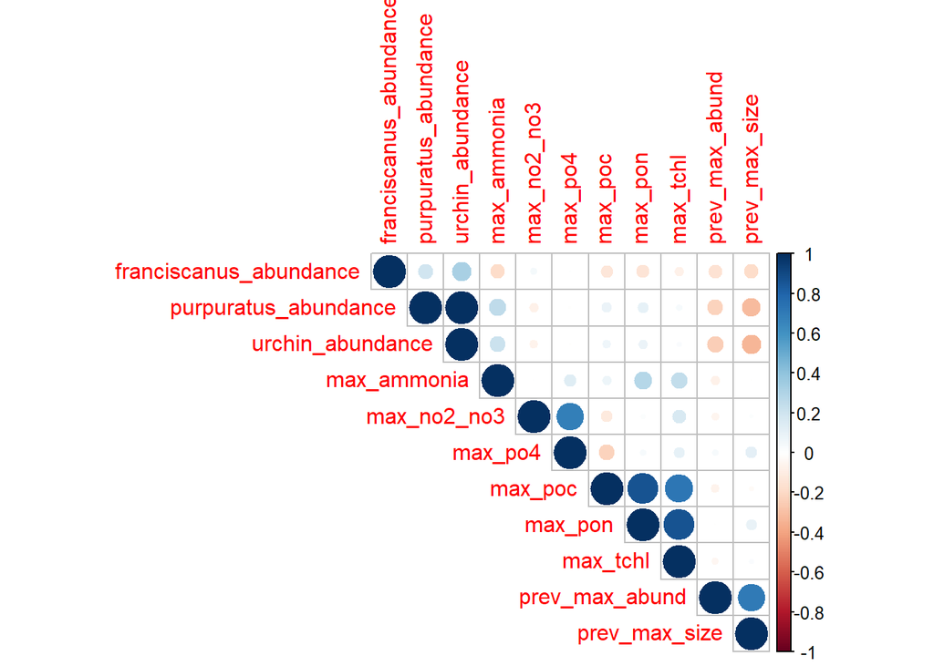

```r
corrplot(cor(mydat[,c(9:17,29,31)],use="complete.obs"), type="upper")
```

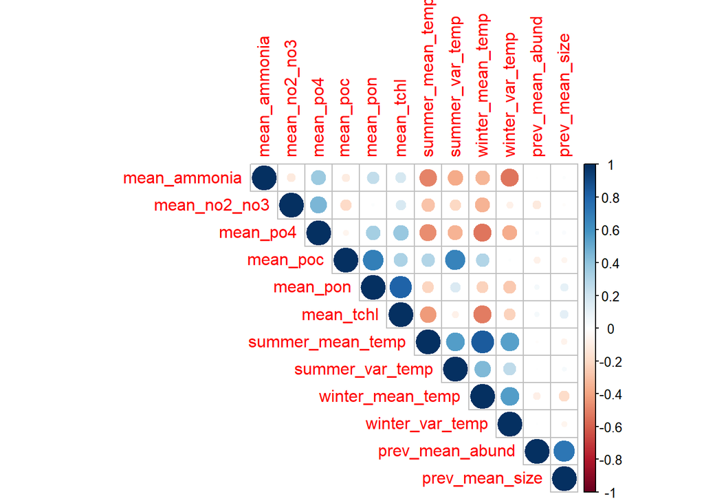

```r
corrplot(cor(mydat[,c(18:28,30)], use="complete.obs"), type="upper")
```

We have three variables that quantify urchin abundance - we’ll just work with total abundance (`urchin_abundance`).

Summer and winter temperatures are correlated; since kelp is a cold-water species, we’ll stick with summer temperature only. But then summer temperatures are also highly correlated with a variety of water chemistry variables, so let’s just take out temperature entirely.

Nitrogen and phosphorus are correlated, as are particulate organic carbon and nitrogen. Particulate organic nitrogen is highly correlated with total chlorophyll. So we’ll just concentrate on nitrogetn (`no2_no3`) and particulate organic carbon (`poc`).

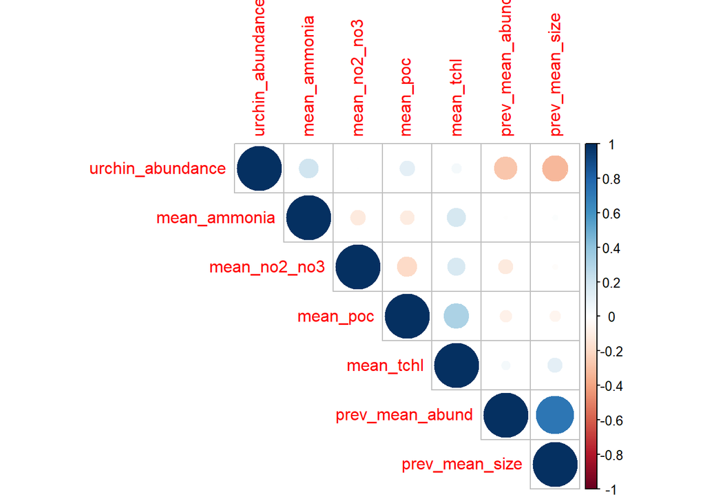

```r
lmdat <- mydat %>%
  dplyr::select(-purpuratus_abundance,-franciscanus_abundance, -max_po4, -mean_po4,
                -mean_pon,-max_pon,-summer_mean_temp,-winter_mean_temp,-winter_var_temp, -summer_var_temp)
corrplot(cor(lmdat[,c(9,14:18,20)],use="complete.obs"),type="upper")
```

## Model Selection & Diagnostics

### Size of Giant Kelp

#### Fit model

```r
n <- dim(lmdat)[1]
fit.a <- lm(mapy_mean_size ~ urchin_abundance+site+
              mean_no2_no3+mean_ammonia+mean_tchl+
              prev_mean_size+site*prev_mean_size,data=lmdat)
scp <- list(lower = ~ 1,
           upper = ~ urchin_abundance+site+
              mean_no2_no3+mean_ammonia+mean_tchl+
              prev_mean_size+site*prev_mean_size)

fit.f <- step(fit.a, scope = scp, direction = "backward",  k = log(n))
```

```
## Start:  AIC=1354.38
## mapy_mean_size ~ urchin_abundance + site + mean_no2_no3 + mean_ammonia +
##     mean_tchl + prev_mean_size + site * prev_mean_size
##
##                       Df Sum of Sq   RSS    AIC
## - site:prev_mean_size  4    847.12 63959 1334.1
## - mean_no2_no3         1      4.29 63116 1348.6
## - mean_tchl            1     63.72 63175 1348.8
## - mean_ammonia         1    985.85 64097 1352.1
## <none>                             63111 1354.4
## - urchin_abundance     1   2357.93 65469 1356.8
##
## Step:  AIC=1334.1
## mapy_mean_size ~ urchin_abundance + site + mean_no2_no3 + mean_ammonia +
##     mean_tchl + prev_mean_size
##
##                    Df Sum of Sq   RSS    AIC
## - mean_no2_no3      1       0.1 63959 1328.3
## - mean_tchl         1      95.4 64054 1328.6
## - mean_ammonia      1    1149.0 65108 1332.3
## <none>                          63959 1334.1
## - urchin_abundance  1    2504.4 66463 1337.0
## - site              4   11376.9 75335 1347.8
## - prev_mean_size    1    6465.8 70424 1350.0
##
## Step:  AIC=1328.28
## mapy_mean_size ~ urchin_abundance + site + mean_ammonia + mean_tchl +
##     prev_mean_size
##
##                    Df Sum of Sq   RSS    AIC
## - mean_tchl         1      99.2 64058 1322.8
## - mean_ammonia      1    1150.2 65109 1326.5
## <none>                          63959 1328.3
## - urchin_abundance  1    2504.4 66463 1331.1
## - prev_mean_size    1    6561.9 70521 1344.5
## - site              4   12572.5 76531 1345.5
##
## Step:  AIC=1322.81
## mapy_mean_size ~ urchin_abundance + site + mean_ammonia + prev_mean_size
##
##                    Df Sum of Sq   RSS    AIC
## - mean_ammonia      1    1100.7 65159 1320.8
## <none>                          64058 1322.8
## - urchin_abundance  1    2582.0 66640 1325.9
## - prev_mean_size    1    6539.9 70598 1339.0
## - site              4   12815.6 76874 1340.7
##
## Step:  AIC=1320.84
## mapy_mean_size ~ urchin_abundance + site + prev_mean_size
##
##                    Df Sum of Sq   RSS    AIC
## <none>                          65159 1320.8
## - urchin_abundance  1    2229.0 67388 1322.6
## - prev_mean_size    1    6870.4 72029 1337.7
## - site              4   13994.6 79153 1341.5
```

```r
n <- dim(lmdat)[1]
fit.e <- lm(mapy_mean_size ~ 1,data=lmdat)

fit.f <- step(fit.e, scope = scp, direction = "forward",  k = log(n))
```

[output not shown]

```r
summary(fit.f)
```

```
##
## Call:
## lm(formula = mapy_mean_size ~ urchin_abundance + site + prev_mean_size,
##     data = lmdat)
##
## Residuals:
##     Min      1Q  Median      3Q     Max
## -46.353 -10.400  -1.330   8.404  70.825
##
## Coefficients:
##                  Estimate Std. Error t value Pr(>|t|)
## (Intercept)      24.58696    4.98905   4.928 1.64e-06 ***
## urchin_abundance -0.04807    0.01756  -2.737  0.00671 **
## siteAQUE         26.86216    5.69641   4.716 4.29e-06 ***
## siteCARP         -0.59219    5.56521  -0.106  0.91536
## siteMOHK         11.03111    5.76830   1.912  0.05713 .
## siteNAPL         -0.62712    4.89781  -0.128  0.89823
## prev_mean_size    0.30071    0.06258   4.805 2.87e-06 ***
## ---
## Signif. codes:  0 '***' 0.001 '**' 0.01 '*' 0.05 '.' 0.1 ' ' 1
##
## Residual standard error: 17.25 on 219 degrees of freedom
##   (112 observations deleted due to missingness)
## Multiple R-squared:  0.4733, Adjusted R-squared:  0.4589
## F-statistic:  32.8 on 6 and 219 DF,  p-value: < 2.2e-16
```

How does RSE / R squared compare to full model

```r
summary(fit.a)
```

```
##
## Call:
## lm(formula = mapy_mean_size ~ urchin_abundance + site + mean_no2_no3 +
##     mean_ammonia + mean_tchl + prev_mean_size + site * prev_mean_size,
##     data = lmdat)
##
## Residuals:
##     Min      1Q  Median      3Q     Max
## -50.563 -10.060  -0.783   7.995  65.277
##
## Coefficients:
##                          Estimate Std. Error t value Pr(>|t|)
## (Intercept)             19.221779  11.140185   1.725  0.08590 .
## urchin_abundance        -0.050855   0.018070  -2.814  0.00535 **
## siteAQUE                19.387275  11.153141   1.738  0.08361 .
## siteCARP                -3.076418   9.686097  -0.318  0.75109
## siteMOHK                13.466558  13.893943   0.969  0.33353
## siteNAPL                 5.028620   9.917753   0.507  0.61266
## mean_no2_no3             0.001059   0.008815   0.120  0.90453
## mean_ammonia             0.009203   0.005057   1.820  0.07020 .
## mean_tchl               -0.373559   0.807403  -0.463  0.64408
## prev_mean_size           0.261606   0.199493   1.311  0.19116
## siteAQUE:prev_mean_size  0.136417   0.221997   0.614  0.53954
## siteCARP:prev_mean_size  0.026147   0.239873   0.109  0.91330
## siteMOHK:prev_mean_size -0.049049   0.305722  -0.160  0.87269
## siteNAPL:prev_mean_size -0.156356   0.250486  -0.624  0.53316
## ---
## Signif. codes:  0 '***' 0.001 '**' 0.01 '*' 0.05 '.' 0.1 ' ' 1
##
## Residual standard error: 17.25 on 212 degrees of freedom
##   (112 observations deleted due to missingness)
## Multiple R-squared:  0.4899, Adjusted R-squared:  0.4586
## F-statistic: 15.66 on 13 and 212 DF,  p-value: < 2.2e-16
```

#### Model Diagnostics

It looks like this model may violate the normality assumption, but there don’t appear to be any outliers.

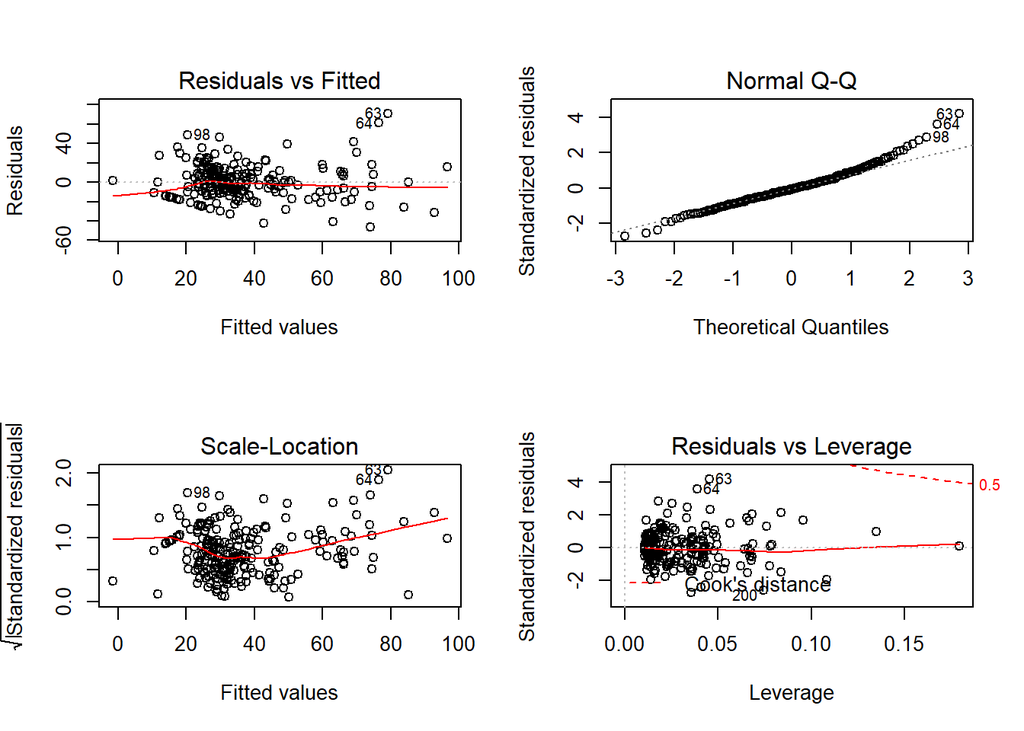

```r
par(mfrow=c(2,2))
plot(fit.f)
```

Here is the right tail on the residuals:

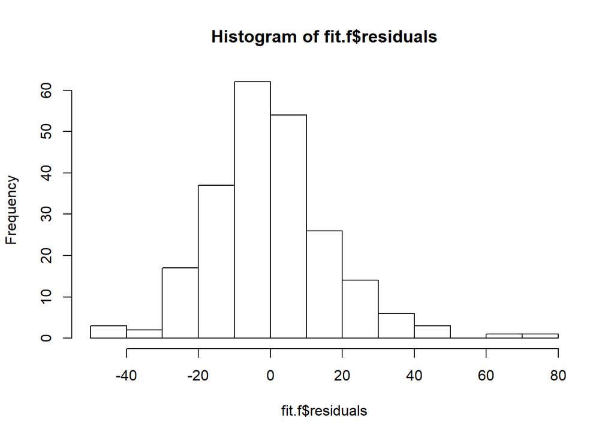

```r
hist(fit.f$residuals)
```

### Abundance of Giant Kelp

#### Fit Model

```r
n <- dim(lmdat)[1]
fit.abund.e <- lm(mapy_mean_abund ~ 1,data=lmdat)
fit.abund.a <- lm(mapy_mean_abund ~ urchin_abundance+site+
              mean_no2_no3+mean_ammonia+mean_tchl+
              prev_mean_abund+site*prev_mean_abund,data=lmdat)
scp <- list(lower = ~ 1,
           upper = ~ urchin_abundance+site+
              mean_no2_no3+mean_ammonia+mean_tchl+
              prev_mean_abund+site*prev_mean_abund)

fit.abund.f <- step(fit.abund.e, scope = scp, direction = "forward",  k = log(n))
```

```
## Start:  AIC=-235.4
## mapy_mean_abund ~ 1
##
##                    Df Sum of Sq    RSS     AIC
## + site              4    45.461 120.10 -320.61
## + prev_mean_abund   1    27.230 138.33 -290.32
## + urchin_abundance  1    16.895 148.67 -265.96
## + mean_no2_no3      1     4.312 161.25 -238.50
## <none>                          165.56 -235.40
## + mean_ammonia      1     0.360 165.20 -230.32
## + mean_tchl         1     0.057 165.51 -229.70
##
## Step:  AIC=-320.61
## mapy_mean_abund ~ site
##
##                    Df Sum of Sq    RSS     AIC
## + prev_mean_abund   1    4.3533 115.75 -327.27
## + urchin_abundance  1    3.8473 116.25 -325.79
## <none>                          120.10 -320.61
## + mean_ammonia      1    1.0568 119.05 -317.78
## + mean_no2_no3      1    0.6321 119.47 -316.57
## + mean_tchl         1    0.0604 120.04 -314.96
##
## Step:  AIC=-327.27
## mapy_mean_abund ~ site + prev_mean_abund
##
##                        Df Sum of Sq    RSS     AIC
## + urchin_abundance      1   2.98567 112.76 -330.28
## <none>                              115.75 -327.27
## + mean_ammonia          1   1.10081 114.65 -324.68
## + mean_no2_no3          1   0.58765 115.16 -323.17
## + mean_tchl             1   0.01706 115.73 -321.50
## + site:prev_mean_abund  4   0.78212 114.97 -306.27
##
## Step:  AIC=-330.28
## mapy_mean_abund ~ site + prev_mean_abund + urchin_abundance
##
##                        Df Sum of Sq    RSS     AIC
## <none>                              112.76 -330.28
## + mean_ammonia          1   1.55213 111.21 -329.14
## + mean_no2_no3          1   0.84237 111.92 -326.99
## + mean_tchl             1   0.00020 112.76 -324.46
## + site:prev_mean_abund  4   1.12792 111.64 -310.38
```

```r
fit.abund.f <- step(fit.abund.a, direction = "backward",  k = log(n))
```

```
## Start:  AIC=-300.23
## mapy_mean_abund ~ urchin_abundance + site + mean_no2_no3 + mean_ammonia +
##     mean_tchl + prev_mean_abund + site * prev_mean_abund
##
##                        Df Sum of Sq    RSS     AIC
## - site:prev_mean_abund  4    1.1898 110.43 -319.86
## - mean_tchl             1    0.0334 109.28 -305.95
## - mean_no2_no3          1    0.7711 110.02 -303.68
## - mean_ammonia          1    1.5161 110.76 -301.40
## <none>                              109.24 -300.23
## - urchin_abundance      1    4.0054 113.25 -293.89
##
## Step:  AIC=-319.86
## mapy_mean_abund ~ urchin_abundance + site + mean_no2_no3 + mean_ammonia +
##     mean_tchl + prev_mean_abund
##
##                    Df Sum of Sq    RSS     AIC
## - mean_tchl         1    0.0265 110.46 -325.61
## - mean_no2_no3      1    0.7479 111.18 -323.41
## - mean_ammonia      1    1.4871 111.92 -321.17
## <none>                          110.43 -319.86
## - prev_mean_abund   1    3.3644 113.80 -315.54
## - urchin_abundance  1    3.6330 114.07 -314.75
## - site              4   15.1438 125.58 -299.72
##
## Step:  AIC=-325.61
## mapy_mean_abund ~ urchin_abundance + site + mean_no2_no3 + mean_ammonia +
##     prev_mean_abund
##
##                    Df Sum of Sq    RSS     AIC
## - mean_no2_no3      1    0.7510 111.21 -329.14
## - mean_ammonia      1    1.4607 111.92 -326.99
## <none>                          110.46 -325.61
## - prev_mean_abund   1    3.4006 113.86 -321.18
## - urchin_abundance  1    3.6777 114.14 -320.36
## - site              4   15.2281 125.69 -305.25
##
## Step:  AIC=-329.14
## mapy_mean_abund ~ urchin_abundance + site + mean_ammonia + prev_mean_abund
##
##                    Df Sum of Sq    RSS     AIC
## - mean_ammonia      1    1.5521 112.76 -330.28
## <none>                          111.21 -329.14
## - urchin_abundance  1    3.4370 114.65 -324.68
## - prev_mean_abund   1    3.4785 114.69 -324.55
## - site              4   16.9864 128.20 -304.39
##
## Step:  AIC=-330.28
## mapy_mean_abund ~ urchin_abundance + site + prev_mean_abund
##
##                    Df Sum of Sq    RSS     AIC
## <none>                          112.76 -330.28
## - urchin_abundance  1    2.9857 115.75 -327.27
## - prev_mean_abund   1    3.4917 116.25 -325.79
## - site              4   17.8255 130.59 -303.96
```

```r
summary(fit.abund.f)
```

```
##
## Call:
## lm(formula = mapy_mean_abund ~ urchin_abundance + site + prev_mean_abund,
##     data = lmdat)
##
## Residuals:
##     Min      1Q  Median      3Q     Max
## -1.2397 -0.2896 -0.1114  0.1867  4.2254
##
## Coefficients:
##                   Estimate Std. Error t value Pr(>|t|)
## (Intercept)       0.470189   0.118499   3.968 8.90e-05 ***
## urchin_abundance -0.001178   0.000398  -2.960  0.00329 **
## siteAQUE          0.807592   0.163478   4.940 1.24e-06 ***
## siteCARP         -0.033482   0.137530  -0.243  0.80780
## siteMOHK          0.497337   0.165298   3.009  0.00282 **
## siteNAPL         -0.054717   0.128156  -0.427  0.66969
## prev_mean_abund   0.176045   0.054989   3.201  0.00150 **
## ---
## Signif. codes:  0 '***' 0.001 '**' 0.01 '*' 0.05 '.' 0.1 ' ' 1
##
## Residual standard error: 0.5837 on 331 degrees of freedom
## Multiple R-squared:  0.3189, Adjusted R-squared:  0.3066
## F-statistic: 25.83 on 6 and 331 DF,  p-value: < 2.2e-16
```

```r
summary(fit.abund.a)
```

```
##
## Call:
## lm(formula = mapy_mean_abund ~ urchin_abundance + site + mean_no2_no3 +
##     mean_ammonia + mean_tchl + prev_mean_abund + site * prev_mean_abund,
##     data = lmdat)
##
## Residuals:
##     Min      1Q  Median      3Q     Max
## -1.2262 -0.2939 -0.1158  0.1944  4.2148
##
## Coefficients:
##                            Estimate Std. Error t value Pr(>|t|)
## (Intercept)               0.4434361  0.2372841   1.869 0.062553 .
## urchin_abundance         -0.0013965  0.0004052  -3.447 0.000642 ***
## siteAQUE                  0.8902606  0.2588195   3.440 0.000659 ***
## siteCARP                  0.0708754  0.1570213   0.451 0.652022
## siteMOHK                  0.6623307  0.2402637   2.757 0.006170 **
## siteNAPL                  0.0814390  0.1524173   0.534 0.593489
## mean_no2_no3             -0.0003212  0.0002124  -1.512 0.131447
## mean_ammonia              0.0002715  0.0001280   2.121 0.034722 *
## mean_tchl                -0.0056149  0.0178433  -0.315 0.753210
## prev_mean_abund           0.3239860  0.1061466   3.052 0.002459 **
## siteAQUE:prev_mean_abund -0.1723657  0.1712462  -1.007 0.314908
## siteCARP:prev_mean_abund -0.2622406  0.1458449  -1.798 0.073095 .
## siteMOHK:prev_mean_abund -0.2195159  0.1915698  -1.146 0.252691
## siteNAPL:prev_mean_abund -0.1194620  0.1785973  -0.669 0.504042
## ---
## Signif. codes:  0 '***' 0.001 '**' 0.01 '*' 0.05 '.' 0.1 ' ' 1
##
## Residual standard error: 0.5807 on 324 degrees of freedom
## Multiple R-squared:  0.3402, Adjusted R-squared:  0.3137
## F-statistic: 12.85 on 13 and 324 DF,  p-value: < 2.2e-16
```

#### Model Diagnostics

A bunch of things look weird here: the TA plot shows a fan shape, suggesting that our estimates are less precise at higher values. The model also violates the assumption of normality, with a right tail on the residuals.

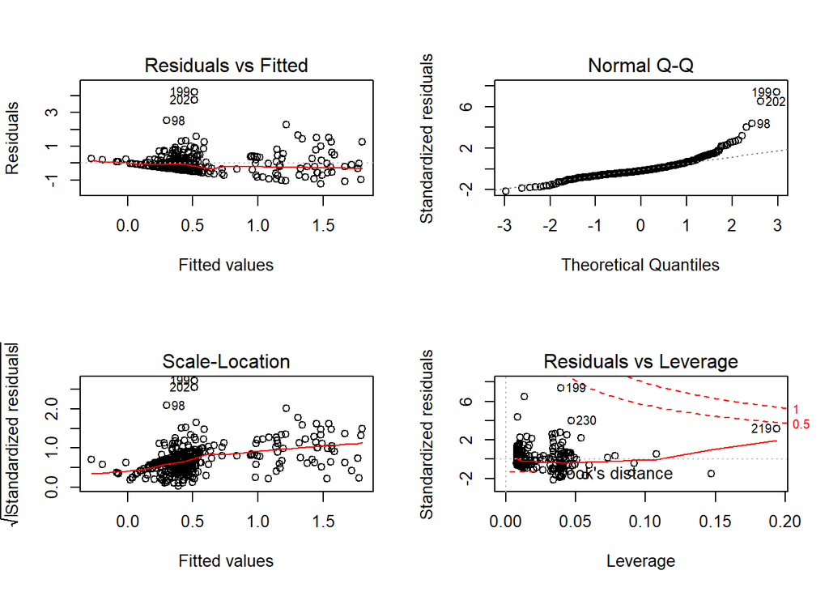

```r
par(mfrow=c(2,2))
plot(fit.abund.f)
```

Here is the right tail on the residuals:

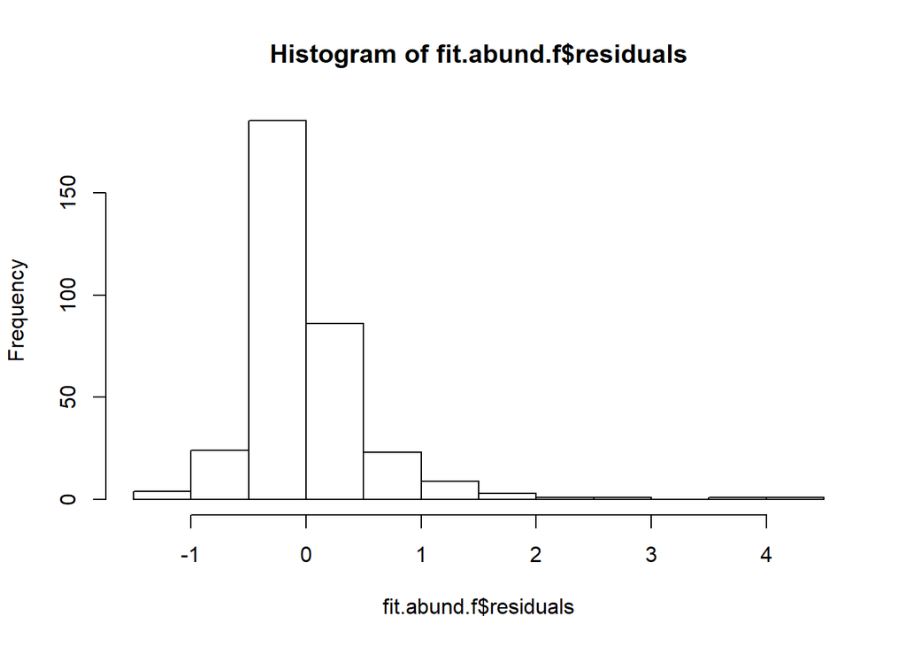

```r
hist(fit.abund.f$residuals)
```